# Value and Consumption Low vs Higher Unemployment Insurance Comparison

[Fan Wang](https://fanwangecon.github.io/)

2021-12-06

# 1 Value and Consumption Low vs Higher Unemployment Insurance Comparison

This is the example vignette for function: [**snw_vfi_main_bisec_vec**](https://github.com/FanWangEcon/PrjOptiSNW/tree/master/PrjOptiSNW/svalpol/snw_vfi_main_bisec_vec.m) from the [**PrjOptiSNW Package**](https://fanwangecon.github.io/PrjOptiSNW/)**.** This function solves for the V(states, unemployed) assuming individuals suffer from unemployment spell, but with different UI (unemployment benefits). Higher UI benefits leads to value/welfare and also higher consumption.

## 1.1 Solve the Steady-State non-unemployment Problem

Solve for Value/Policy in non-COVID years, then solve for covid year value/policy given covid shocks. COVID lasts one period.

```
% mp_params = snw_mp_param('default_dense');
mp_params = snw_mp_param('default_docdense');
mp_params('beta') = 0.95;
mp_controls = snw_mp_control('default_test');
mp_controls('bl_print_vfi') = false;
mp_controls('bl_timer') = true;
[V_ss,~,cons_ss,~] = snw_vfi_main_bisec_vec(mp_params, mp_controls);

Completed SNW_VFI_MAIN_BISEC_VEC;SNW_MP_PARAM=default_docdense;SNW_MP_CONTROL=default_test;time=491.2252
----------------------------------------
xxxxxxxxxxxxxxxxxxxxxxxxxxxxxxxxxxxxxxxx
CONTAINER NAME: mp_outcomes ND Array (Matrix etc)
xxxxxxxxxxxxxxxxxxxxxxxxxxxxxxxxxxxxxxxx
                i    idx    ndim     numel      rowN      colN           sum         mean       std      coefvari      min          max
                _    ___    ____    ________    ____    _________    ___________    _______    ______    ________    ________    __________

    V_VFI       1     1      6      4.37e+07     83     5.265e+05    -6.6619e+08    -15.245    21.865    -1.4343      -504.39    -0.0071775
    ap_VFI      2     2      6      4.37e+07     83     5.265e+05     1.3967e+09     31.962    36.426     1.1397            0        160.24
    cons_VFI    3     3      6      4.37e+07     83     5.265e+05     2.3276e+08     5.3263    8.4413     1.5848     0.036717        141.61

xxx TABLE:V_VFI xxxxxxxxxxxxxxxxxx
             c1         c2         c3         c4         c5        c526496      c526497      c526498      c526499      c526500
           _______    _______    _______    _______    _______    _________    _________    _________    _________    _________

    r1     -293.96    -293.57    -291.09    -285.44    -276.41      -4.3584      -4.2643      -4.1713      -4.0795      -3.9885
    r2     -284.42    -284.03    -281.55    -275.97    -267.24      -4.2519      -4.1612      -4.0717      -3.9832      -3.8955
    r3     -274.87    -274.48    -272.03    -266.62    -258.33      -4.1429      -4.0559      -3.9698      -3.8847      -3.8002
    r4     -265.22    -264.86    -262.58    -257.53    -249.74      -4.0309      -3.9475      -3.8649      -3.7833      -3.7017
    r5     -256.51    -256.17    -254.04     -249.3    -241.96      -3.9252      -3.8452      -3.7659      -3.6873      -3.6084
    r79    -13.642    -13.628    -13.535    -13.298    -12.896     -0.22092     -0.21058     -0.20086     -0.19173     -0.18315
    r80    -12.283    -12.269    -12.176    -11.939    -11.537     -0.16979     -0.16182      -0.1543     -0.14722     -0.14057
    r81    -10.605    -10.591    -10.498    -10.261    -9.8589     -0.11712     -0.11163     -0.10646     -0.10157     -0.09695
    r82    -8.3494    -8.3358    -8.2424    -8.0055    -7.6035    -0.065333    -0.062242     -0.05936    -0.056635    -0.054056
    r83    -5.0665    -5.0529    -4.9595    -4.7226    -4.3206    -0.020968    -0.019972    -0.019038    -0.018161    -0.017336

xxx TABLE:ap_VFI xxxxxxxxxxxxxxxxxx
           c1    c2        c3           c4           c5       c526496    c526497    c526498    c526499    c526500
           __    __    __________    _________    ________    _______    _______    _______    _______    _______

    r1     0     0     0.00051498    0.0066578    0.021589    112.13     117.67      123.4     129.31     135.72
```

[output cut: 9 more lines]

```

xxx TABLE:cons_VFI xxxxxxxxxxxxxxxxxx
              c1          c2          c3          c4          c5       c526496    c526497    c526498    c526499    c526500
           ________    ________    ________    ________    ________    _______    _______    _______    _______    _______

    r1     0.036717    0.037251    0.040477    0.044486    0.049324    12.265      12.55     12.844     13.145     13.145
    r2     0.036717    0.037251    0.040477    0.045375    0.050668    12.501     12.787     13.082     13.383     13.383
    r3     0.036717    0.037251    0.040784    0.046998    0.052374    12.755     13.042     13.337     13.638     13.638
    r4     0.038144    0.038678    0.042314    0.048449    0.054031        13     13.289     13.584     13.883     13.883
    r5     0.039534    0.040068    0.043802    0.049839    0.055635    13.236     13.525     13.821     14.116     14.116
    r79     0.19737     0.19791     0.20163     0.21175     0.23145    35.811     37.362     39.409       41.7     44.025
    r80     0.19737     0.19791     0.20163     0.21175     0.23145    40.752     42.953     45.286     47.946     50.769
    r81     0.19737     0.19791     0.20163     0.21175     0.23145    48.909     52.039     55.022     57.919     60.234
    r82     0.19737     0.19791     0.20163     0.21175     0.23145     66.71     69.193     72.375     77.007      80.72
    r83     0.19737     0.19791     0.20163     0.21175     0.23145    116.82     122.65     128.66     134.88     141.29
```

## 1.2 Solve Problem in MIT Unemployed State with High and Low Unemployment Insurance

Shared xi value, 50 percent income loss. This is a one-time MIT shock that changes choices today in the sense of changing the resource state-space, but does not change forward expectations.

```
xi=0.5; % xi=0 full income loss from covid shock, xi=1, no covid income losses
```

Solve for $b=0$, no unemployment insurane.

```
fl_b_lower = 0.0;
fl_b_higher= 0.5;
b=fl_b_lower; % b=0 means no UI benefits compensating COVID, b=1 if full income replacement
mp_params('xi') = xi;
mp_params('b') = b;
mp_params('a2_covidyr') = mp_params('a2_covidyr_manna_heaven');
% mp_params('a2_covidyr') = mp_params('a2_covidyr_tax_fully_pay');
[V_unemp_b_0p0,~,cons_unemp_b_0p0,~] = snw_vfi_main_bisec_vec(mp_params, mp_controls, V_ss);

Completed SNW_VFI_MAIN_BISEC_VEC 1 Period Unemp Shock;SNW_MP_PARAM=default_docdense;SNW_MP_CONTROL=default_test;time=485.5335
----------------------------------------
xxxxxxxxxxxxxxxxxxxxxxxxxxxxxxxxxxxxxxxx
CONTAINER NAME: mp_outcomes ND Array (Matrix etc)
xxxxxxxxxxxxxxxxxxxxxxxxxxxxxxxxxxxxxxxx
                i    idx    ndim     numel      rowN      colN           sum         mean       std      coefvari      min          max
                _    ___    ____    ________    ____    _________    ___________    _______    ______    ________    ________    __________

    V_VFI       1     1      6      4.37e+07     83     5.265e+05    -6.8822e+08    -15.749    22.879    -1.4527      -563.56    -0.0071775
    ap_VFI      2     2      6      4.37e+07     83     5.265e+05     1.3605e+09     31.134    36.294     1.1657            0        143.42
    cons_VFI    3     3      6      4.37e+07     83     5.265e+05     2.2887e+08     5.2375    8.4438     1.6122     0.018623        140.47

xxx TABLE:V_VFI xxxxxxxxxxxxxxxxxx
             c1         c2         c3         c4         c5        c526496      c526497      c526498      c526499      c526500
           _______    _______    _______    _______    _______    _________    _________    _________    _________    _________

    r1     -320.42    -318.92    -310.39    -296.97    -284.58      -4.4406      -4.3429      -4.2464      -4.1513      -4.0575
    r2     -310.88    -309.38    -300.85    -287.43    -275.14      -4.3331       -4.239      -4.1461      -4.0543      -3.9639
    r3     -301.33    -299.83     -291.3    -277.88    -265.85      -4.2231      -4.1327      -4.0433       -3.955      -3.8679
    r4     -290.68    -289.29    -281.32     -268.6     -257.1      -4.1145      -4.0276      -3.9417      -3.8567      -3.7729
    r5     -281.05    -279.76    -272.29     -260.2    -249.16      -4.0121      -3.9284      -3.8457      -3.7638      -3.6828
    r79    -13.642    -13.628    -13.535    -13.298    -12.896     -0.22291     -0.21238     -0.20247     -0.19317     -0.18445
    r80    -12.283    -12.269    -12.176    -11.939    -11.537     -0.17128     -0.16316     -0.15551      -0.1483     -0.14154
    r81    -10.605    -10.591    -10.498    -10.261    -9.8589     -0.11815     -0.11254     -0.10726     -0.10231    -0.097637
    r82    -8.3494    -8.3358    -8.2424    -8.0055    -7.6035    -0.065887    -0.062757    -0.059823    -0.057044    -0.054433
    r83    -5.0665    -5.0529    -4.9595    -4.7226    -4.3206    -0.021146    -0.020134    -0.019185    -0.018294    -0.017458

xxx TABLE:ap_VFI xxxxxxxxxxxxxxxxxx
           c1    c2    c3    c4       c5        c526496    c526497    c526498    c526499    c526500
           __    __    __    __    _________    _______    _______    _______    _______    _______

```

[output cut: 10 more lines]

```

xxx TABLE:cons_VFI xxxxxxxxxxxxxxxxxx
              c1          c2          c3          c4          c5       c526496    c526497    c526498    c526499    c526500
           ________    ________    ________    ________    ________    _______    _______    _______    _______    _______

    r1     0.018623    0.019158    0.022901    0.033062    0.044486    11.989     12.265      12.55     12.844     13.145
    r2     0.018623    0.019158    0.022901    0.033062    0.045375    12.223     12.501     12.787     13.082     13.383
    r3     0.018623    0.019158    0.022901    0.033062    0.046998    12.476     12.755     13.042     13.337     13.638
    r4     0.019354    0.019888    0.023632    0.033792    0.048579     12.72         13     13.289     13.584     13.883
    r5     0.020066    0.020601    0.024344    0.034504    0.050114    12.955     13.236     13.525     13.821     14.116
    r79     0.19737     0.19791     0.20163     0.21175     0.23145    35.417     37.362     39.409       41.7     44.025
    r80     0.19737     0.19791     0.20163     0.21175     0.23145    40.752     42.953     45.286     47.946     49.897
    r81     0.19737     0.19791     0.20163     0.21175     0.23145    48.909     52.039     55.022     57.241     59.234
    r82     0.19737     0.19791     0.20163     0.21175     0.23145    65.719     68.202     72.375     76.948     79.729
    r83     0.19737     0.19791     0.20163     0.21175     0.23145    115.84     121.66     127.68     133.89     140.31
```

Solve for $b=0.5$, 50 percent unemployment insurance, meaning 50 percent of lost income is recovered.

```
b=fl_b_higher; % b=0 means no UI benefits compensating COVID, b=1 if full income replacement
mp_params('xi') = xi;
mp_params('b') = b;
mp_params('a2_covidyr') = mp_params('a2_covidyr_manna_heaven');
% mp_params('a2_covidyr') = mp_params('a2_covidyr_tax_fully_pay');
[V_unemp_b_0p5,~,cons_unemp_b_0p5,~] = snw_vfi_main_bisec_vec(mp_params, mp_controls, V_ss);

Completed SNW_VFI_MAIN_BISEC_VEC 1 Period Unemp Shock;SNW_MP_PARAM=default_docdense;SNW_MP_CONTROL=default_test;time=488.1425
----------------------------------------
xxxxxxxxxxxxxxxxxxxxxxxxxxxxxxxxxxxxxxxx
CONTAINER NAME: mp_outcomes ND Array (Matrix etc)
xxxxxxxxxxxxxxxxxxxxxxxxxxxxxxxxxxxxxxxx
                i    idx    ndim     numel      rowN      colN           sum         mean       std      coefvari      min          max
                _    ___    ____    ________    ____    _________    ___________    _______    ______    ________    ________    __________

    V_VFI       1     1      6      4.37e+07     83     5.265e+05    -6.7567e+08    -15.462    22.251    -1.4391      -524.15    -0.0071775
    ap_VFI      2     2      6      4.37e+07     83     5.265e+05     1.3783e+09     31.541     36.36     1.1528            0        151.82
    cons_VFI    3     3      6      4.37e+07     83     5.265e+05     2.3114e+08     5.2893    8.4402     1.5957     0.027723        141.04

xxx TABLE:V_VFI xxxxxxxxxxxxxxxxxx
             c1         c2         c3         c4         c5        c526496      c526497      c526498      c526499      c526500
           _______    _______    _______    _______    _______    _________    _________    _________    _________    _________

    r1      -302.8    -302.11    -297.97     -290.4    -280.12      -4.3991      -4.3032      -4.2086      -4.1151       -4.023
    r2     -293.25    -292.57    -288.43    -280.86     -270.8      -4.2921      -4.1998      -4.1086      -4.0185      -3.9297
    r3      -283.7    -283.02    -278.88    -271.34    -261.75      -4.1826       -4.094      -4.0063      -3.9196       -3.834
    r4     -273.72    -273.09    -269.23    -262.13     -253.1      -4.0721       -3.987      -3.9028      -3.8196      -3.7373
    r5      -264.7    -264.11    -260.51    -253.79    -245.27      -3.9679      -3.8861      -3.8051       -3.725      -3.6456
    r79    -13.642    -13.628    -13.535    -13.298    -12.896     -0.22191     -0.21148     -0.20167     -0.19245      -0.1838
    r80    -12.283    -12.269    -12.176    -11.939    -11.537     -0.17053     -0.16249      -0.1549     -0.14776     -0.14105
    r81    -10.605    -10.591    -10.498    -10.261    -9.8589     -0.11764     -0.11208     -0.10686     -0.10194    -0.097291
    r82    -8.3494    -8.3358    -8.2424    -8.0055    -7.6035    -0.065608    -0.062497    -0.059592    -0.056839    -0.054243
    r83    -5.0665    -5.0529    -4.9595    -4.7226    -4.3206    -0.021056    -0.020052    -0.019111    -0.018227    -0.017397

xxx TABLE:ap_VFI xxxxxxxxxxxxxxxxxx
           c1    c2    c3        c4           c5       c526496    c526497    c526498    c526499    c526500
           __    __    __    __________    ________    _______    _______    _______    _______    _______

    r1     0     0     0      0.0011815    0.013905    109.98     115.52     121.26     127.18     133.29
    r2     0     0     0     0.00090277    0.013905    109.95     115.49     121.22     127.14     133.26
```

[output cut: 8 more lines]

```

xxx TABLE:cons_VFI xxxxxxxxxxxxxxxxxx
              c1          c2          c3          c4          c5       c526496    c526497    c526498    c526499    c526500
           ________    ________    ________    ________    ________    _______    _______    _______    _______    _______

    r1     0.027723    0.028258    0.031999    0.040974    0.048028    11.989     12.265      12.55     12.844     13.145
    r2     0.027723    0.028258    0.031999    0.041253    0.048028    12.223     12.501     12.787     13.082     13.383
    r3     0.027723    0.028258    0.031999    0.041641    0.048028    12.476     12.755     13.042     13.337     13.638
    r4     0.028805    0.029339    0.033081    0.042722    0.049108     12.72         13     13.289     13.584     13.883
    r5     0.029859    0.030394    0.034135    0.043802    0.050161    12.955     13.236     13.525     13.821     14.116
    r79     0.19737     0.19791     0.20163     0.21175     0.23145    35.417     37.362     39.409       41.7     44.025
    r80     0.19737     0.19791     0.20163     0.21175     0.23145    40.752     42.953     45.286     47.946     50.402
    r81     0.19737     0.19791     0.20163     0.21175     0.23145    48.909     52.039     55.022     57.741     59.734
    r82     0.19737     0.19791     0.20163     0.21175     0.23145    66.215     68.697     72.375     77.007     80.224
    r83     0.19737     0.19791     0.20163     0.21175     0.23145    116.33     122.15     128.17     134.39      140.8
```

## 1.3 Generate UI Comparison Matrixes

Find the deviation in value and consumption between higher and lower UI world. Welfare is converted to units in fixed life-time consumption.

```
gamma = mp_params('gamma');
mn_V_U_gain_moreUI = snw_hh_welfare(V_unemp_b_0p5, gamma) - snw_hh_welfare(V_unemp_b_0p0, gamma);
mn_C_U_gain_moreUI = cons_unemp_b_0p5 - cons_unemp_b_0p0;
```

## 1.4 Dense Param Results Define Frames

Define the matrix dimensions names and dimension vector values. Policy and Value Functions share the same ND dimensional structure.

```
% Grids:
age_grid = 18:100;
agrid = mp_params('agrid')';
eta_H_grid = mp_params('eta_H_grid')';
eta_S_grid = mp_params('eta_S_grid')';
ar_st_eta_HS_grid = string(cellstr([num2str(eta_H_grid', 'hz=%3.2f;'), num2str(eta_S_grid', 'wz=%3.2f')]));
edu_grid = [0,1];
marry_grid = [0,1];
kids_grid = (1:1:mp_params('n_kidsgrid'))';
% NaN(n_jgrid,n_agrid,n_etagrid,n_educgrid,n_marriedgrid,n_kidsgrid);
cl_mp_datasetdesc = {};
cl_mp_datasetdesc{1} = containers.Map({'name', 'labval'}, {'age', age_grid});
cl_mp_datasetdesc{2} = containers.Map({'name', 'labval'}, {'savings', agrid});
cl_mp_datasetdesc{3} = containers.Map({'name', 'labval'}, {'eta', 1:length(eta_H_grid)});
cl_mp_datasetdesc{4} = containers.Map({'name', 'labval'}, {'edu', edu_grid});
cl_mp_datasetdesc{5} = containers.Map({'name', 'labval'}, {'marry', marry_grid});
cl_mp_datasetdesc{6} = containers.Map({'name', 'labval'}, {'kids', kids_grid});
```

## 1.5 Analyze Difference in V and C with Higher and Lower UI

The difference between V and C with higher and ower UI.

```
% Generate some Data
mp_support_graph = containers.Map('KeyType', 'char', 'ValueType', 'any');
mp_support_graph('cl_st_xtitle') = {'Savings States, a'};
mp_support_graph('st_legend_loc') = 'eastoutside';
mp_support_graph('bl_graph_logy') = true; % do not log
mp_support_graph('it_legend_select') = 21; % how many shock legends to show
mp_support_graph('cl_colors') = 'jet';
```

MEAN(MN_V_GAIN(A,Z))

Tabulate value and policies along savings and shocks:

```
% Set
ar_permute = [1,4,5,6,3,2];
% Value Function
st_title = ['MEAN(MN_V_U_GAIN(A,Z)), b\_lower=' num2str(fl_b_lower) ', b\_higher=' num2str(fl_b_higher)];
tb_az_v = ff_summ_nd_array(st_title, mn_V_U_gain_moreUI, true, ["mean"], 4, 1, cl_mp_datasetdesc, ar_permute);

xxx  MEAN(MN_V_U_GAIN(A,Z)), b\_lower=0, b\_higher=0.5  xxxxxxxxxxxxxxxxxxxxxxxxxxx
    group     savings      mean_eta_1    mean_eta_2    mean_eta_3    mean_eta_4    mean_eta_5    mean_eta_6    mean_eta_7    mean_eta_8    mean_eta_9    mean_eta_10    mean_eta_11    mean_eta_12    mean_eta_13    mean_eta_14    mean_eta_15    mean_eta_16    mean_eta_17    mean_eta_18    mean_eta_19 …
    _____    __________    __________    __________    __________    __________    __________    __________    __________    __________    __________    ___________    ___________    ___________    ___________    ___________    ___________    ___________    ___________    ___________    ___________ …

      1               0    0.00064445    0.00064585    0.00064898     0.0006533    0.00065831    0.00066363    0.00066902    0.00067435    0.00067953    0.00068451     0.00068927     0.00069379     0.00069809     0.00070215     0.00070599     0.00070962     0.00071307     0.00071636     0.00071951  …
      2      0.00051498    0.00063531    0.00063705    0.00064049    0.00064511    0.00065039    0.00065598    0.00066164    0.00066723    0.00067266     0.0006779     0.00068291     0.00068768     0.00069222     0.00069652     0.00070059     0.00070445     0.00070812     0.00071163     0.00071499  …
      3       0.0041199    0.00057709    0.00058077    0.00058599    0.00059228    0.00059918    0.00060635    0.00061356     0.0006207    0.00062768    0.00063445     0.00064099     0.00064728     0.00065331     0.00065909     0.00066462     0.00066992     0.00067499     0.00067987     0.00068456  …
      4        0.013905    0.00045712    0.00046361    0.00047138    0.00048007    0.00048933    0.00049886    0.00050849    0.00051809    0.00052761    0.00053698     0.00054617     0.00055515     0.00056392     0.00057246     0.00058077     0.00058884     0.00059669     0.00060432     0.00061175  …
      5        0.032959    0.00031724    0.00032482    0.00033328    0.00034248    0.00035224    0.00036242    0.00037287    0.00038352     0.0003943    0.00040516     0.00041606     0.00042697     0.00043784     0.00044865     0.00045939     0.00047002     0.00048054     0.00049095     0.00050123  …
      6        0.064373    0.00020749    0.00021431    0.00022165    0.00022943    0.00023758    0.00024613    0.00025499    0.00026408    0.00027338    0.00028289     0.00029265     0.00030264     0.00031283     0.00032323     0.00033384     0.00034462     0.00035558     0.00036671     0.00037798  …

% Consumption
st_title = ['MEAN(MN_C_U_GAIN(A,Z)), b\_lower=' num2str(fl_b_lower) ', b\_higher=' num2str(fl_b_higher)];
tb_az_c = ff_summ_nd_array(st_title, mn_C_U_gain_moreUI, true, ["mean"], 4, 1, cl_mp_datasetdesc, ar_permute);

xxx  MEAN(MN_C_U_GAIN(A,Z)), b\_lower=0, b\_higher=0.5  xxxxxxxxxxxxxxxxxxxxxxxxxxx
    group     savings      mean_eta_1    mean_eta_2    mean_eta_3    mean_eta_4    mean_eta_5    mean_eta_6    mean_eta_7    mean_eta_8    mean_eta_9    mean_eta_10    mean_eta_11    mean_eta_12    mean_eta_13    mean_eta_14    mean_eta_15    mean_eta_16    mean_eta_17    mean_eta_18    mean_eta_19 …
    _____    __________    __________    __________    __________    __________    __________    __________    __________    __________    __________    ___________    ___________    ___________    ___________    ___________    ___________    ___________    ___________    ___________    ___________ …

      1               0     0.0097329      0.010306      0.010916      0.011565      0.012255       0.01299      0.013772      0.014604      0.015489      0.016431       0.017433       0.018499       0.019632       0.020839       0.022122       0.023486       0.024938       0.026483       0.028126  …
      2      0.00051498     0.0097327      0.010306      0.010915      0.011564      0.012255       0.01299      0.013772      0.014604      0.015489      0.016431       0.017433       0.018498       0.019632       0.020838       0.022121       0.023486       0.024938       0.026482       0.028125  …
      3       0.0041199     0.0097314      0.010304      0.010914      0.011563      0.012253      0.012988       0.01377      0.014602      0.015487      0.016429       0.017431       0.018497        0.01963       0.020836       0.022119       0.023484       0.024936        0.02648       0.028123  …
      4        0.013905     0.0097157      0.010288      0.010899      0.011551      0.012243      0.012981      0.013764      0.014598      0.015483      0.016424       0.017426       0.018492       0.019626       0.020832       0.022114       0.023479       0.024931       0.026475       0.028118  …
      5        0.032959     0.0081866     0.0087007     0.0093519      0.010139      0.011012      0.011899      0.012824      0.013761      0.014781      0.015872       0.017004       0.018187       0.019401       0.020668       0.021996       0.023391       0.024862       0.026421       0.028079  …
      6        0.064373     0.0066453     0.0069797     0.0073187     0.0077166     0.0083191     0.0090933     0.0097907      0.010529      0.011313      0.012257       0.013378       0.014587        0.01594       0.017438       0.018954       0.020578       0.022409       0.024321       0.026314  …
```

Graph Mean Values:

```
st_title = ['MEAN(MN\_V\_U\_GAIN(A,Z)), b\_lower=' num2str(fl_b_lower) ', b\_higher=' num2str(fl_b_higher)];
mp_support_graph('cl_st_graph_title') = {st_title};
mp_support_graph('cl_st_ytitle') = {'MEAN(MN\_V\_U\_GAIN(a,z))'};
ff_graph_grid((tb_az_v{1:end, 3:end})', ar_st_eta_HS_grid, agrid, mp_support_graph);
```

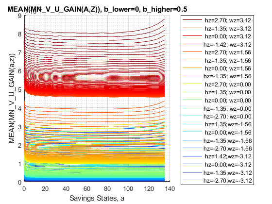

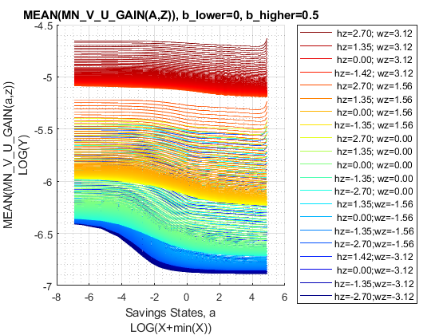

Graph Mean Consumption:

```
st_title = ['MEAN(MN\_C\_U\_GAIN(A,Z)), b\_lower=' num2str(fl_b_lower) ', b\_higher=' num2str(fl_b_higher)];
mp_support_graph('cl_st_graph_title') = {st_title};
mp_support_graph('cl_st_ytitle') = {'MEAN(MN\_C\_U\_GAIN(a,z))'};
ff_graph_grid((tb_az_c{1:end, 3:end})', ar_st_eta_HS_grid, agrid, mp_support_graph);
```

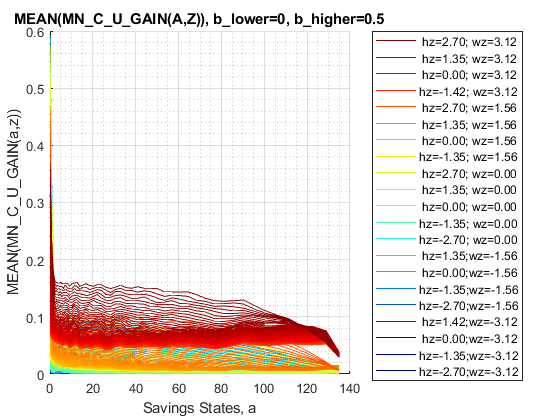

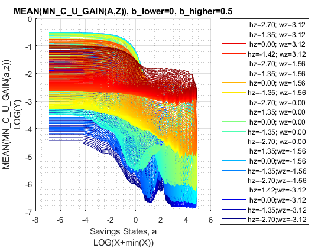

## 1.6 Analyze Kids and Marriage and Age

Aggregating over education, savings, and shocks, what are the differential effects of Marriage and Age.

```
% Generate some Data
mp_support_graph = containers.Map('KeyType', 'char', 'ValueType', 'any');
ar_row_grid = [...
    "k0M0", "K1M0", "K2M0", "K3M0", "K4M0", ...
    "k0M1", "K1M1", "K2M1", "K3M1", "K4M1"];
mp_support_graph('cl_st_xtitle') = {'Age'};
mp_support_graph('st_legend_loc') = 'best';
mp_support_graph('bl_graph_logy') = true; % do not log
mp_support_graph('st_rounding') = '6.2f'; % format shock legend
mp_support_graph('cl_scatter_shapes') = {...
    'o', 'd' ,'s', 'x', '*', ...
    'o', 'd', 's', 'x', '*'};
mp_support_graph('cl_colors') = {...
    'red', 'red', 'red', 'red', 'red'...
    'blue', 'blue', 'blue', 'blue', 'blue'};
```

MEAN(VAL(KM,J)), MEAN(AP(KM,J)), MEAN(C(KM,J))

Tabulate value and policies:

```
% Set
% NaN(n_jgrid,n_agrid,n_etagrid,n_educgrid,n_marriedgrid,n_kidsgrid);
ar_permute = [2,3,4,1,6,5];
% Value Function
st_title = ['MEAN(MN_V_U_GAIN(KM,J)), b\_lower=' num2str(fl_b_lower) ', b\_higher=' num2str(fl_b_higher)];
tb_az_v = ff_summ_nd_array(st_title, mn_V_U_gain_moreUI, true, ["mean"], 3, 1, cl_mp_datasetdesc, ar_permute);

xxx  MEAN(MN_V_U_GAIN(KM,J)), b\_lower=0, b\_higher=0.5  xxxxxxxxxxxxxxxxxxxxxxxxxxx
    group    kids    marry    mean_age_18    mean_age_19    mean_age_20    mean_age_21    mean_age_22    mean_age_23    mean_age_24    mean_age_25    mean_age_26    mean_age_27    mean_age_28    mean_age_29    mean_age_30    mean_age_31    mean_age_32    mean_age_33    mean_age_34    mean_age_35    …
    _____    ____    _____    ___________    ___________    ___________    ___________    ___________    ___________    ___________    ___________    ___________    ___________    ___________    ___________    ___________    ___________    ___________    ___________    ___________    ___________    …

      1       1        0      0.00055672     0.00057552     0.00059522     0.00063544     0.00067622     0.00071737     0.00075873     0.00080011     0.00084132     0.00088219     0.00092252     0.00096217       0.001001      0.0010389      0.0010758      0.0011116      0.0011464      0.0011802     …
      2       2        0      0.00048244     0.00050035     0.00051966     0.00055508     0.00059141     0.00062848     0.00066617      0.0007043     0.00074272     0.00078126     0.00081974     0.00085798     0.00089581     0.00093311     0.00096976      0.0010057      0.0010408       0.001075     …
      3       3        0      0.00046167     0.00047833     0.00049636     0.00052804     0.00056045     0.00059347     0.00062698     0.00066087     0.00069503     0.00072932     0.00076362     0.00079778     0.00083169     0.00086525     0.00089835     0.00093092      0.0009629     0.00099423     …
      4       4        0      0.00043771     0.00045259     0.00046877     0.00049707     0.00052603     0.00055556     0.00058556     0.00061595     0.00064663      0.0006775     0.00070846      0.0007394      0.0007702     0.00080078     0.00083106     0.00086096     0.00089043      0.0009194     …
      5       5        0      0.00042439     0.00043747     0.00045169      0.0004768     0.00050238     0.00052835     0.00055464     0.00058121     0.00060798     0.00063489     0.00066186     0.00068881     0.00071567     0.00074236     0.00076884     0.00079505     0.00082093     0.00084646     …
      6       1        1       0.0008562     0.00090669     0.00095849      0.0010295      0.0011022      0.0011763      0.0012513      0.0013269      0.0014027      0.0014782      0.0015532      0.0016271      0.0016998      0.0017708      0.0018399      0.0019068      0.0019713      0.0020333     …
      7       2        1      0.00071993     0.00075882     0.00079903     0.00085585     0.00091452     0.00097487      0.0010366      0.0010994      0.0011629       0.001227      0.0012911       0.001355      0.0014183      0.0014808      0.0015422      0.0016023      0.0016607      0.0017174     …
      8       3        1      0.00066704     0.00070046     0.00073484     0.00078384      0.0008343     0.00088607     0.00093891      0.0009926      0.0010469      0.0011016      0.0011564       0.001211      0.0012651      0.0013186      0.0013712      0.0014227      0.0014729      0.0015217     …
      9       4        1      0.00061227     0.00064001     0.00066838     0.00070987     0.00075249     0.00079613     0.00084063     0.00088583     0.00093156     0.00097762      0.0010238        0.00107      0.0011158      0.0011612      0.0012059      0.0012499      0.0012928      0.0013347     …
     10       5        1      0.00055284     0.00057485       0.000597     0.00063042     0.00066449     0.00069912     0.00073419     0.00076962     0.00080531      0.0008411     0.00087683     0.00091237     0.00094762     0.00098246      0.0010168      0.0010504      0.0010834      0.0011155     …

% Consumption Function
st_title = ['MEAN(MN_C_U_GAIN(KM,J)), b\_lower=' num2str(fl_b_lower) ', b\_higher=' num2str(fl_b_higher)];
tb_az_c = ff_summ_nd_array(st_title, mn_C_U_gain_moreUI, true, ["mean"], 3, 1, cl_mp_datasetdesc, ar_permute);

```

[output cut: 14 more lines]

Graph Mean Values:

```
st_title = ['MEAN(MN\_V\_U\_GAIN(KM,J)), b\_lower=' num2str(fl_b_lower) ', b\_higher=' num2str(fl_b_higher)];
mp_support_graph('cl_st_graph_title') = {st_title};
mp_support_graph('cl_st_ytitle') = {'MEAN(MN\_V\_U\_GAIN(KM,J))'};
ff_graph_grid((tb_az_v{1:end, 4:end}), ar_row_grid, age_grid, mp_support_graph);
```

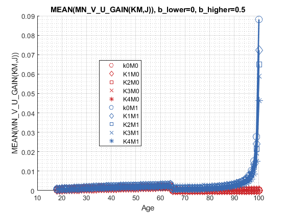

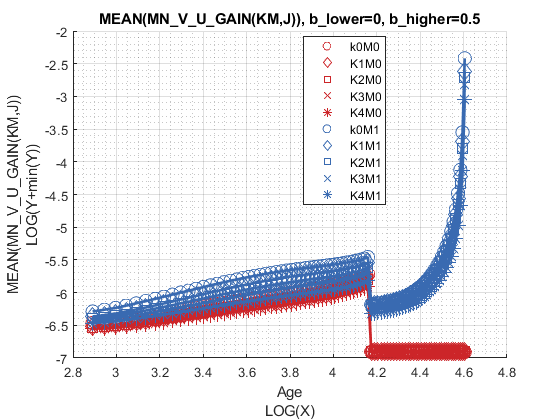

Graph Mean Consumption:

```
st_title = ['MEAN(MN\_C\_U\_GAIN(KM,J)), b\_lower=' num2str(fl_b_lower) ', b\_higher=' num2str(fl_b_higher)];
mp_support_graph('cl_st_graph_title') = {st_title};
mp_support_graph('cl_st_ytitle') = {'MEAN(MN\_C\_U\_GAIN(KM,J))'};
ff_graph_grid((tb_az_c{1:end, 4:end}), ar_row_grid, age_grid, mp_support_graph);
```

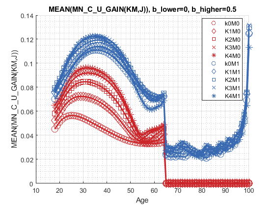

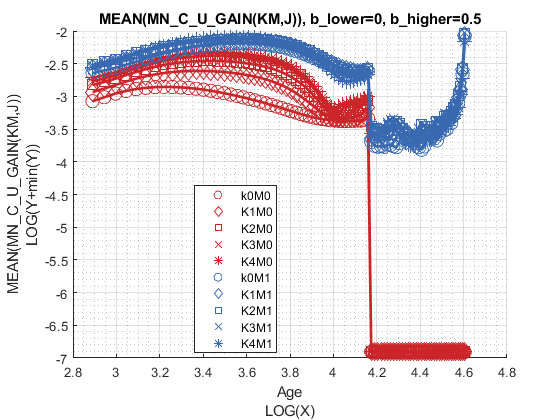

## 1.7 Analyze Education and Marriage

```
% Generate some Data
mp_support_graph = containers.Map('KeyType', 'char', 'ValueType', 'any');
ar_row_grid = ["E0M0", "E1M0", "E0M1", "E1M1"];
mp_support_graph('cl_st_xtitle') = {'Age'};
mp_support_graph('st_legend_loc') = 'best';
mp_support_graph('bl_graph_logy') = true; % do not log
mp_support_graph('st_rounding') = '6.2f'; % format shock legend
mp_support_graph('cl_scatter_shapes') = {'*', 'p', '*','p' };
mp_support_graph('cl_colors') = {'red', 'red', 'blue', 'blue'};
```

MEAN(VAL(EM,J)), MEAN(AP(EM,J)), MEAN(C(EM,J))

Tabulate value and policies:

```
% Set
% NaN(n_jgrid,n_agrid,n_etagrid,n_educgrid,n_marriedgrid,n_kidsgrid);
ar_permute = [2,3,6,1,4,5];
% Value Function
st_title = ['MEAN(MN_V_U_GAIN(EM,J)), b\_lower=' num2str(fl_b_lower) ', b\_higher=' num2str(fl_b_higher)];
tb_az_v = ff_summ_nd_array(st_title, mn_V_U_gain_moreUI, true, ["mean"], 3, 1, cl_mp_datasetdesc, ar_permute);

xxx  MEAN(MN_V_U_GAIN(EM,J)), b\_lower=0, b\_higher=0.5  xxxxxxxxxxxxxxxxxxxxxxxxxxx
    group    edu    marry    mean_age_18    mean_age_19    mean_age_20    mean_age_21    mean_age_22    mean_age_23    mean_age_24    mean_age_25    mean_age_26    mean_age_27    mean_age_28    mean_age_29    mean_age_30    mean_age_31    mean_age_32    mean_age_33    mean_age_34    mean_age_35    m…
    _____    ___    _____    ___________    ___________    ___________    ___________    ___________    ___________    ___________    ___________    ___________    ___________    ___________    ___________    ___________    ___________    ___________    ___________    ___________    ___________    _…

      1       0       0      0.00044711     0.00045939     0.00047231     0.00049626     0.00052045     0.00054482     0.00056933     0.00059395     0.00061864     0.00064335     0.00066805     0.00069269     0.00071723     0.00074164     0.00076592     0.00079004     0.00081399     0.00083776     0…
      2       1       0      0.00049806     0.00051832     0.00054037     0.00058072     0.00062215     0.00066447      0.0007075     0.00075102     0.00079483     0.00083871     0.00088243     0.00092577     0.00096852      0.0010105      0.0010516      0.0010917      0.0011306      0.0011684      …
      3       0       1      0.00062246     0.00065265     0.00068378     0.00072512     0.00076731     0.00081022      0.0008537     0.00089759     0.00094179      0.0009861      0.0010303      0.0010744       0.001118      0.0011611      0.0012036      0.0012452      0.0012859      0.0013256      …
      4       1       1      0.00074086     0.00077968     0.00081932     0.00087866      0.0009399      0.0010028       0.001067      0.0011321       0.001198      0.0012641      0.0013302      0.0013958      0.0014606      0.0015244      0.0015868      0.0016476      0.0017065      0.0017635      …

% Consumption
st_title = ['MEAN(MN_C_U_GAIN(EM,J)), b\_lower=' num2str(fl_b_lower) ', b\_higher=' num2str(fl_b_higher)];
tb_az_c = ff_summ_nd_array(st_title, mn_C_U_gain_moreUI, true, ["mean"], 3, 1, cl_mp_datasetdesc, ar_permute);

xxx  MEAN(MN_C_U_GAIN(EM,J)), b\_lower=0, b\_higher=0.5  xxxxxxxxxxxxxxxxxxxxxxxxxxx
    group    edu    marry    mean_age_18    mean_age_19    mean_age_20    mean_age_21    mean_age_22    mean_age_23    mean_age_24    mean_age_25    mean_age_26    mean_age_27    mean_age_28    mean_age_29    mean_age_30    mean_age_31    mean_age_32    mean_age_33    mean_age_34    mean_age_35    m…
    _____    ___    _____    ___________    ___________    ___________    ___________    ___________    ___________    ___________    ___________    ___________    ___________    ___________    ___________    ___________    ___________    ___________    ___________    ___________    ___________    _…

      1       0       0       0.047852       0.050213       0.052704       0.054124        0.05542       0.056592       0.057655         0.0586       0.059438       0.060177       0.060799       0.061307       0.061703       0.061974       0.062132       0.062181       0.062109       0.061885       …
      2       1       0       0.065172       0.068522       0.072143       0.077638       0.082599       0.086879       0.090455       0.093288       0.095372       0.096773       0.097568       0.097851       0.097709       0.097244       0.096536       0.095567       0.094471       0.093232       …
      3       0       1        0.06735       0.070027       0.072677       0.075227       0.077714       0.080007       0.082374       0.084508       0.086416       0.088357       0.090096       0.091595       0.092953       0.094262       0.095398       0.096279       0.096963       0.097422       …
      4       1       1       0.084746       0.088978       0.093461       0.099707        0.10567        0.11101        0.11598        0.12029        0.12417         0.1277        0.13056        0.13278        0.13459        0.13602        0.13709        0.13779        0.13811        0.13814       …
```

Graph Mean Values:

```
st_title = ['MEAN(MN\_V\_U\_GAIN(EM,J)), b\_lower=' num2str(fl_b_lower) ', b\_higher=' num2str(fl_b_higher)];
mp_support_graph('cl_st_graph_title') = {st_title};
mp_support_graph('cl_st_ytitle') = {'MEAN(MN\_V\_U\_GAIN(EM,J))'};
ff_graph_grid((tb_az_v{1:end, 4:end}), ar_row_grid, age_grid, mp_support_graph);
```

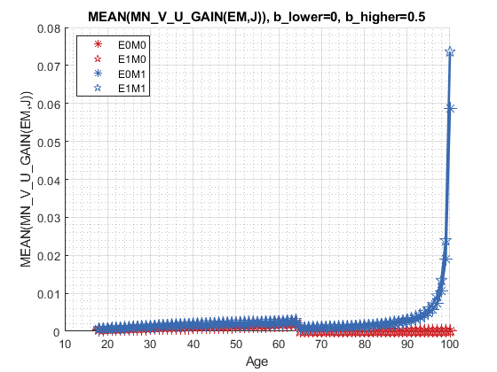

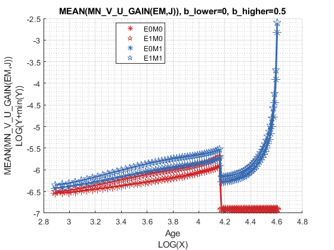

Graph Mean Consumption:

```
st_title = ['MEAN(MN\_C\_U\_GAIN(EM,J)), b\_lower=' num2str(fl_b_lower) ', b\_higher=' num2str(fl_b_higher)];
mp_support_graph('cl_st_graph_title') = {st_title};
mp_support_graph('cl_st_ytitle') = {'MEAN(MN\_C\_U\_GAIN(EM,J))'};
ff_graph_grid((tb_az_c{1:end, 4:end}), ar_row_grid, age_grid, mp_support_graph);
```

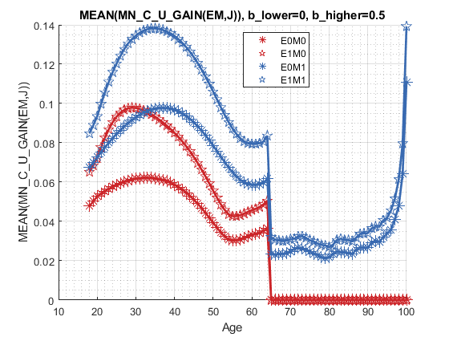

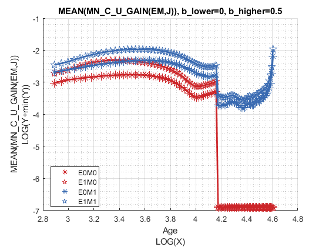